# Step 1: Importing Required Libraries

In this first step, we import the necessary Python libraries:

- **pandas**: For data manipulation and analysis.
- **matplotlib** & **seaborn**: For creating static data visualizations.
- **plotly.express**: For creating interactive plots like choropleth maps.
- **datetime**: For working with and formatting dates.

We also set a global visualization style using Seaborn’s `darkgrid` to keep our plots consistent and visually appealing throughout the notebook.

```python
# Importing Required Libraries
import pandas as pd
import matplotlib.pyplot as plt
import seaborn as sns
import plotly.express as px
from datetime import datetime
import warnings
warnings.simplefilter(action='ignore', category=FutureWarning)
# Set plot style
sns.set(style="darkgrid")
```

## Step 2: Load the COVID-19 Dataset

We load the cleaned COVID-19 dataset from **Our World in Data** using `pandas.read_csv()`. This dataset contains global information on:

- Total and new COVID-19 cases
- Deaths
- Vaccinations
- Testing
- Hospitalizations and more

```python
# Step 2: Load the Dataset
# Dataset: Our World in Data COVID-19 data
file_path = "data/owid-covid-data.csv"
df = pd.read_csv(file_path)
```

## Step 3: Initial Data Exploration

We inspect the dataset by:

- Checking the shape (rows and columns)
- Viewing all column names
- Displaying the first few rows using `head()`

This helps us understand the dataset's structure and spot important fields like `total_cases`, `date`, and `location`.

```python
#  Explore the DataFrame
print("DataFrame Shape:", df.shape)
print("\nColumn Names:\n", df.columns.tolist())
```

```
DataFrame Shape: (302512, 67)

Column Names:
 ['iso_code', 'continent', 'location', 'date', 'total_cases', 'new_cases', 'new_cases_smoothed', 'total_deaths', 'new_deaths', 'new_deaths_smoothed', 'total_cases_per_million', 'new_cases_per_million', 'new_cases_smoothed_per_million', 'total_deaths_per_million', 'new_deaths_per_million', 'new_death…
```

```python
# Preview top rows
df.head()
```

|  | iso_code | continent | location | date | total_cases | new_cases | new_cases_smoothed | total_deaths | new_deaths | new_deaths_smoothed | ... | male_smokers | handwashing_facilities | hospital_beds_per_thousand | life_expectancy | human_development_index | population | excess_mortality_cumulative_absolute | excess_mortality_cumulative | excess_mortality | excess_mortality_cumulative_per_million |
| --- | --- | --- | --- | --- | --- | --- | --- | --- | --- | --- | --- | --- | --- | --- | --- | --- | --- | --- | --- | --- | --- |
| 0 | AFG | Asia | Afghanistan | 2020-01-03 | NaN | 0.0 | NaN | NaN | 0.0 | NaN | ... | NaN | 37.746 | 0.5 | 64.83 | 0.511 | 41128772.0 | NaN | NaN | NaN | NaN |
| 1 | AFG | Asia | Afghanistan | 2020-01-04 | NaN | 0.0 | NaN | NaN | 0.0 | NaN | ... | NaN | 37.746 | 0.5 | 64.83 | 0.511 | 41128772.0 | NaN | NaN | NaN | NaN |
| 2 | AFG | Asia | Afghanistan | 2020-01-05 | NaN | 0.0 | NaN | NaN | 0.0 | NaN | ... | NaN | 37.746 | 0.5 | 64.83 | 0.511 | 41128772.0 | NaN | NaN | NaN | NaN |
| 3 | AFG | Asia | Afghanistan | 2020-01-06 | NaN | 0.0 | NaN | NaN | 0.0 | NaN | ... | NaN | 37.746 | 0.5 | 64.83 | 0.511 | 41128772.0 | NaN | NaN | NaN | NaN |
| 4 | AFG | Asia | Afghanistan | 2020-01-07 | NaN | 0.0 | NaN | NaN | 0.0 | NaN | ... | NaN | 37.746 | 0.5 | 64.83 | 0.511 | 41128772.0 | NaN | NaN | NaN | NaN |

5 rows × 67 columns

## Step 4: Identify Missing Data

Many real-world datasets include missing values. Here, we calculate:

- Total missing values in each column
- Sorted in descending order

We will later handle these missing values before performing analysis.

```python
# Check for missing values
missing_values = df.isnull().sum().sort_values(ascending=False)
missing_values[missing_values > 0].head(20)
```

```
weekly_icu_admissions                      293411
weekly_icu_admissions_per_million          293411
excess_mortality_cumulative_absolute       292217
excess_mortality_cumulative_per_million    292217
excess_mortality_cumulative                292217
excess_mortality                           292217
weekly_hosp_admissions_per_million         281225
weekly_hosp_admissions                     281225
icu_patients_per_million                   267748
icu_patients                               267748
hosp_patients_per_million                  267374
hosp_patients                              267374
total_boosters                             260188
total_boosters_per_hundred                 260188
new_vaccinations                           241970
people_fully_vaccinated                    234363
people_fully_vaccinated_per_hundred        234363
people_vaccinated                          232101
people_vaccinated_per_hundred              232101
total_vaccinations_per_hundred             228951
dtype: int64
```

## Step 5: Convert Date Column

To enable time-series analysis, we convert the `date` column from string format to a proper `datetime` object using `pd.to_datetime()`.

```python
# Convert the 'date' column to datetime format
df['date'] = pd.to_datetime(df['date'])
```

## Step 6: Filter Countries for Analysis

We limit our analysis to a selection of countries with varying pandemic experiences:

- Kenya (Africa)
- India (Asia)
- United States (North America)
- Brazil (South America)
- Germany (Europe)

This diversity gives us global perspective.

```python
# Filter for countries of interest
countries = ["Kenya", "India", "United States", "Brazil", "Germany"]
df_filtered = df[df["location"].isin(countries)]
```

```python
df_filtered.head()
```

|  | iso_code | continent | location | date | total_cases | new_cases | new_cases_smoothed | total_deaths | new_deaths | new_deaths_smoothed | ... | male_smokers | handwashing_facilities | hospital_beds_per_thousand | life_expectancy | human_development_index | population | excess_mortality_cumulative_absolute | excess_mortality_cumulative | excess_mortality | excess_mortality_cumulative_per_million |
| --- | --- | --- | --- | --- | --- | --- | --- | --- | --- | --- | --- | --- | --- | --- | --- | --- | --- | --- | --- | --- | --- |
| 35882 | BRA | South America | Brazil | 2020-01-03 | NaN | 0.0 | NaN | NaN | 0.0 | NaN | ... | 17.9 | NaN | 2.2 | 75.88 | 0.765 | 215313504.0 | NaN | NaN | NaN | NaN |
| 35883 | BRA | South America | Brazil | 2020-01-04 | NaN | 0.0 | NaN | NaN | 0.0 | NaN | ... | 17.9 | NaN | 2.2 | 75.88 | 0.765 | 215313504.0 | NaN | NaN | NaN | NaN |
| 35884 | BRA | South America | Brazil | 2020-01-05 | NaN | 0.0 | NaN | NaN | 0.0 | NaN | ... | 17.9 | NaN | 2.2 | 75.88 | 0.765 | 215313504.0 | NaN | NaN | NaN | NaN |
| 35885 | BRA | South America | Brazil | 2020-01-06 | NaN | 0.0 | NaN | NaN | 0.0 | NaN | ... | 17.9 | NaN | 2.2 | 75.88 | 0.765 | 215313504.0 | NaN | NaN | NaN | NaN |
| 35886 | BRA | South America | Brazil | 2020-01-07 | NaN | 0.0 | NaN | NaN | 0.0 | NaN | ... | 17.9 | NaN | 2.2 | 75.88 | 0.765 | 215313504.0 | NaN | NaN | NaN | NaN |

5 rows × 67 columns

## Step 7: Handle Missing Values

We use **forward fill (`ffill`)** and **backward fill (`bfill`)** within each country to fill missing numeric values such as cases or deaths. This is suitable for time series data where missing values often represent "no update" rather than true null.

```python
# Fill missing values within each country group
df_filtered = df_filtered.groupby("location").apply(lambda group: group.ffill().bfill()).reset_index(drop=True)
df_filtered.head()
```

[output not shown]

5 rows × 68 columns

## Step 8: Total COVID-19 Cases Over Time

This line plot shows how total confirmed COVID-19 cases increased over time in each selected country.

- **India** and the **United States** experienced large surges.
- **Kenya** shows a slower and smaller case trajectory.

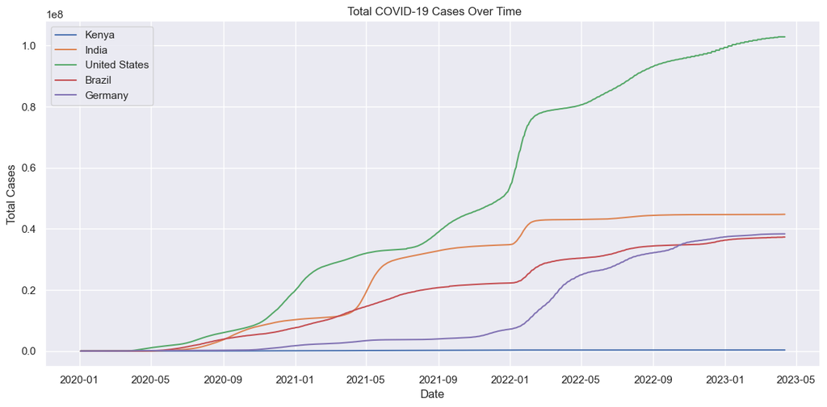

```python
#  Time Series Plot - Total COVID-19 Cases Over Time
import matplotlib.pyplot as plt

plt.figure(figsize=(12, 6))
for country in countries:
    country_data = df_filtered[df_filtered["location"] == country]
    plt.plot(country_data["date"], country_data["total_cases"], label=country)

plt.title(" Total COVID-19 Cases Over Time")
plt.xlabel("Date")
plt.ylabel("Total Cases")
plt.legend()
plt.tight_layout()
plt.show()
```

## Step 9: Total COVID-19 Deaths Over Time

This chart highlights the growth in cumulative deaths. It reflects both:

- Outbreak severity
- Healthcare capacity

The **US** and **Brazil** have high death tolls, while **Kenya** remains relatively low.

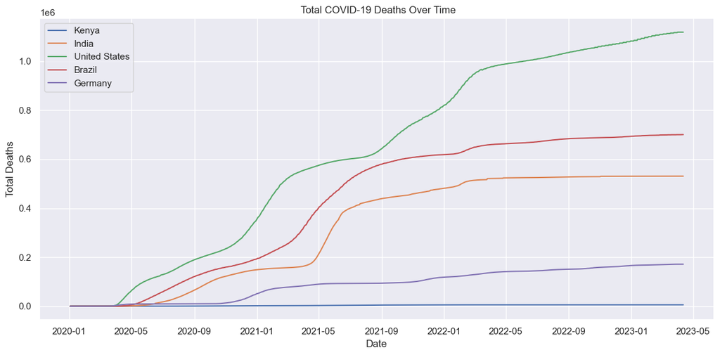

```python
#  Total COVID-19 Deaths Over Time
plt.figure(figsize=(12, 6))
for country in countries:
    country_data = df_filtered[df_filtered["location"] == country]
    plt.plot(country_data["date"], country_data["total_deaths"], label=country)

plt.title(" Total COVID-19 Deaths Over Time")
plt.xlabel("Date")
plt.ylabel("Total Deaths")
plt.legend()
plt.tight_layout()
plt.show()
```

## Step 10: Daily New COVID-19 Cases (7-Day Average)

By plotting the 7-day average of new cases, we smooth out reporting noise and spot:

- Peaks from different COVID-19 waves
- Timing of spikes across countries

India had a major spike in mid-2021 due to the Delta variant.

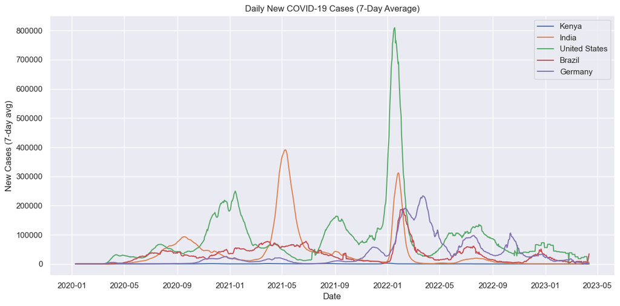

```python
#Daily New Cases (7-Day Rolling Average)
plt.figure(figsize=(12, 6))
for country in countries:
    country_data = df_filtered[df_filtered["location"] == country]
    plt.plot(country_data["date"], country_data["new_cases"].rolling(7).mean(), label=country)

plt.title("Daily New COVID-19 Cases (7-Day Average)")
plt.xlabel("Date")
plt.ylabel("New Cases (7-day avg)")
plt.legend()
plt.tight_layout()
plt.show()
```

## Step 11: Death Rate Over Time

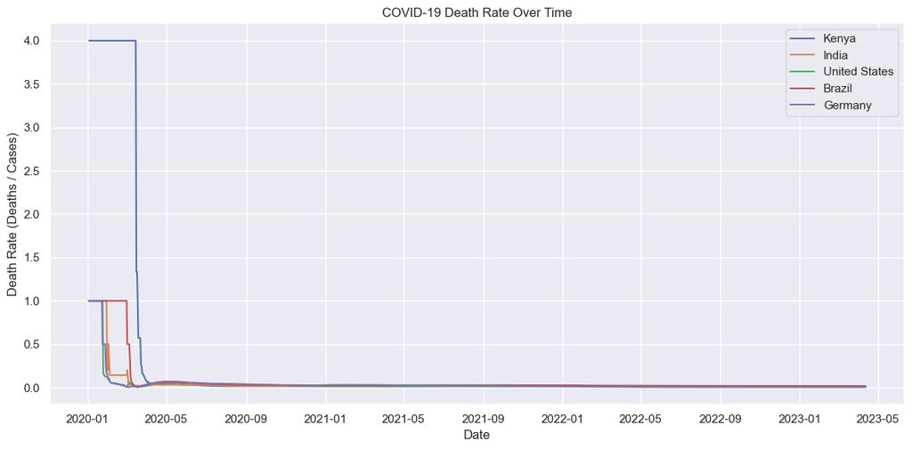

```python
# Calculate and Plot Death Rate Over Time
df_filtered["death_rate"] = df_filtered["total_deaths"] / df_filtered["total_cases"]

plt.figure(figsize=(12, 6))
for country in countries:
    country_data = df_filtered[df_filtered["location"] == country]
    plt.plot(country_data["date"], country_data["death_rate"], label=country)

plt.title("COVID-19 Death Rate Over Time")
plt.xlabel("Date")
plt.ylabel("Death Rate (Deaths / Cases)")
plt.legend()
plt.tight_layout()
plt.show()
```

## Step 12: Vaccination Progress

This chart shows the percentage of people fully vaccinated in each country.

- **Germany** and the **United States** reached high vaccination levels quickly.
- **Kenya** shows slower progress, reflecting disparities in global vaccine distribution.

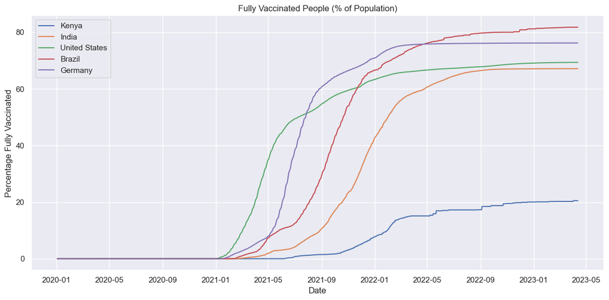

```python
#  Vaccination Progress (% of Population Fully Vaccinated)
plt.figure(figsize=(12, 6))
for country in countries:
    country_data = df_filtered[df_filtered["location"] == country]
    plt.plot(
        country_data["date"],
        country_data["people_fully_vaccinated_per_hundred"],
        label=country
    )

plt.title("Fully Vaccinated People (% of Population)")
plt.xlabel("Date")
plt.ylabel("Percentage Fully Vaccinated")
plt.legend()
plt.tight_layout()
plt.show()
```

## Step 13: Global Map of Total Cases

The choropleth map uses color intensity to show which countries have the highest total COVID-19 cases.

```python
import numpy as np
import plotly.express as px

# Filter the latest data
latest_date = df["date"].max()
latest_data = df[df["date"] == latest_date]

# Prepare the data: keep only valid entries
choropleth_data = latest_data[["iso_code", "location", "total_cases"]].dropna()
choropleth_data = choropleth_data[choropleth_data["total_cases"] > 0]

# log-transformed column for better visualization
choropleth_data["log_total_cases"] = np.log10(choropleth_data["total_cases"])

# Create the choropleth map
fig = px.choropleth(
    choropleth_data,
    locations="iso_code",
    color="log_total_cases",
    hover_name="location",
    hover_data={"total_cases": True, "log_total_cases": False},
    title=f"Total COVID-19 Cases by Country (Log Scale) as of {latest_date.date()}",
    color_continuous_scale="Reds",
    projection="natural earth"
)

fig.update_layout(coloraxis_colorbar=dict(
    title="Log₁₀(Total Cases)",
    tickvals=[3, 4, 5, 6, 7],
    ticktext=["1k", "10k", "100k", "1M", "10M"]
))

fig.show()
```

[interactive chart not shown]

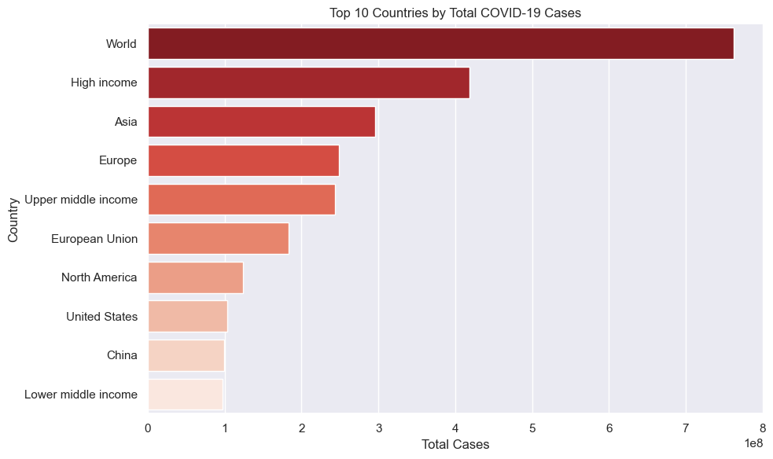

```python
# Top 10 regions by Total Cases (Bar Plot)
top_cases = latest_data.sort_values("total_cases", ascending=False).head(10)

plt.figure(figsize=(10, 6))
sns.barplot(x="total_cases", y="location", data=top_cases, palette="Reds_r")
plt.title("Top 10 Countries by Total COVID-19 Cases")
plt.xlabel("Total Cases")
plt.ylabel("Country")
plt.tight_layout()
plt.show()
```